# Network Analysis for Tokens

Steven Mesquiti

2022-12-06

# Markdown to visualize topic model!

This is a markdown file that demonstrates how to do a network analysis of tokenized text to complement Meaning Extraction Helper.

# Prep

## Load packages

The **job** package is a great package to use for running things with long wait times. You can read more about [job here](https://lindeloev.github.io/job/) if you choose to run it as a script.

```r
if (!require(pacman)) {
  install.packages('pacman')
}
pacman::p_load(tidyverse, tidytext, igraph, ggraph, widyr, job, devtools, install = T)
devtools::install_github("hadley/emo")
```

## Load data and prep the data. Note if you are working with other data this **will** change!

```r
setwd("~/Desktop/CEO Project") #set WD to where our files live

data  <- read.csv(file = "Big_CEO.csv", stringsAsFactors = FALSE)


data <- data["2019-03-01"<= data$Date & data$Date <= "2021-04-01",] #subsetting covid dates
data <- data %>% filter(WC<=5400) %>% #filter out based on our exclusion criteria
  filter(WC>=25)

df <- data[, c(1:9)] #we trimmed it down to include stuff we want
```

## Tokenize the Data… which will take awhile.

```r
df_bigrams <- df %>%
  unnest_tokens(bigram, aggregated_text, token = 'ngrams', n = 2) %>%
  filter(!is.na(bigram))
```

# Starting Network analysis

For this tutorial, we are using the CEO dataset, which is kinda large so note that we trim some stuff and rely on background jobs to speed this up.

## Separate the Data

```r
bigrams_separated <- df_bigrams %>%
  separate(bigram, c("word1", "word2"), sep = " ")
```

## Take out the stop words. Please note, this is the preloaded stop word list, which can be customized.

```r
  bigrams_filtered <- bigrams_separated %>%
  filter(!word1 %in% stop_words$word) %>%
  filter(!word2 %in% stop_words$word)
```

## Counting bigrams and taking *only* high frequency ones :). Please adjust the N to fit your dataset

```r
# new bigram counts:
bigram_counts <- bigrams_filtered %>%
  count(word1, word2, sort = TRUE)

# filter for only relatively common combinations. bigger is better here
bigram_graph <- bigram_counts %>%
  filter(n > 400) %>%
  graph_from_data_frame()
```

# build your network graph

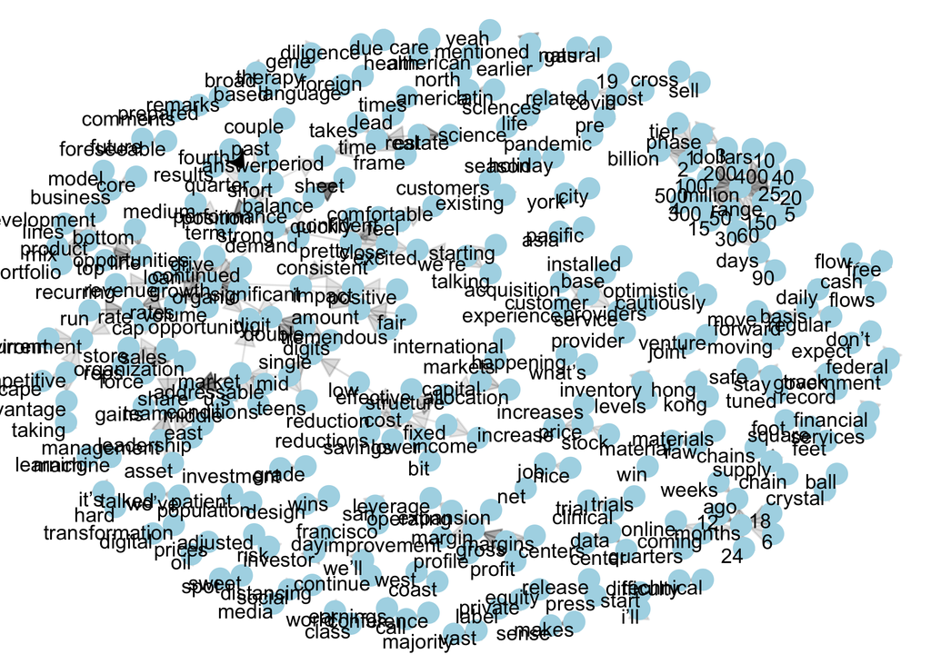

```r
#start building
#more refinedgraph
#start building
set.seed(2020)

a <- grid::arrow(type = "closed", length = unit(.15, "inches"))
ggraph(bigram_graph, layout = "fr") +
  geom_edge_link(aes(edge_alpha = n), show.legend = FALSE,
                 arrow = a, end_cap = circle(.07, 'inches')) +
  geom_node_point(color = "lightblue", size = 5) +
  geom_node_text(aes(label = name), vjust = 1, hjust = 1) +
  theme_void()
```

# Resources

## Reproducible reports in R

- [Improve your workflow for reproducible science - Mine Çetinkaya-Rundel](https://mine-cr.com/talk/2021-improve-workflow-repro-science-oss/)
- [R Markdown for writing reproducible scientific papers - Mike Frank & Chris Hartgerink](https://libscie.github.io/rmarkdown-workshop/handout.html)
- [R Markdown for scientists - Nicholas Tierney](https://rmd4sci.njtierney.com/)
- [Reproducible Analysis with R](https://nceas.github.io/sasap-training/materials/reproducible_research_in_r_fairbanks/)
- [Reproducible science curriculum](https://github.com/Reproducible-Science-Curriculum)

## R Markdown

- [R Markdown](https://rmarkdown.rstudio.com/lesson-1.html)
- [R Markdown reference guide](https://www.rstudio.com/wp-content/uploads/2015/03/rmarkdown-reference.pdf?_ga=2.245086913.571798724.1647284447-1046469491.1644870105)

## Themes

- [R Markdown theme gallery](https://www.datadreaming.org/post/r-markdown-theme-gallery/)
- [{rmdformats} theme package](https://juba.github.io/rmdformats/)